# Exploratory Analysis

Navya, Simrita, Krystal, Uyen

11/22/2021

## Introductory Paragraph

Our group is doing a project on Netflix movies, and we aimed to look into the correlation between IMDB ratings and genres for Netflix Original content, and discover if there were any patterns in the data that might tell us how Netflix chooses to produce its Original Content. Our Dataset was scoured by the user (Luis Corter) from a Wikipedia page, getting base characteristics of Netflix’s original content until June 1st, 2021 and their IMDB scores. There are 584 rows in this dataset, and 6 columns: title, genre(s), original premiere date, runtime (minutes), IMDB scores, and language availability.

## Summary Paragraph

Our Summary Function tells us that the mean of the IMDB score of all Netflix Original movies is a 6.27, that the median of the IMDB score of all Netflix Original movies is a 6.35, that the average runtime of all Netflix Original movies is 93.58, that the most common language of all Netflix Original movies is English, and that the genre with the most number of movies are Documentaries.

## Table Report

The table shows all genres present in the data of Netflix Originals, how many are present, and what the average IMDB score of each genre is. We are able to see that Netflix produces many Documentaries, few Musicals, and films in many genres. We are also able to contextualize data more, as one can come in with a notion that Netflix produces many Action movies, but after seeing the data are able to realize that they produce more Romantic Comedies than Action movies. We are also able to see that the Netflix Animation/Christmas/Comedy/Adventure combination Film scored the highest with an 8.2, and average ratings of Netflix Originals in in specific genres and crossovers.

```
##                 Genre Count Average IMDB Score
##   1:           Action     7               5.41
##   2:    Action comedy     5               5.42
##   3:  Action thriller     1               6.40
##   4: Action-adventure     1               7.30
##   5:  Action-thriller     3               6.13
##  ---
## 111:              War     2               6.75
## 112:        War drama     2               7.10
## 113:       War-Comedy     1               6.00
## 114:          Western     3               6.07
## 115:     Zombie/Heist     1               5.90
```

## Chart 1 Report

Chart 1 shows a bar graph for the average IMDB score in each genre of Netflix Originals. This chart was intended to show the relationship between the genres and scores, which we felt was best represented in a Bar Chart. Because it is a Bar Chart, we are easily able to see that Netflix Original Concert Films score the best of all Netflix Originals, with an average rating of 7.6, and Netflix Original Horror Films score the worst, with an average rating of 5.3.

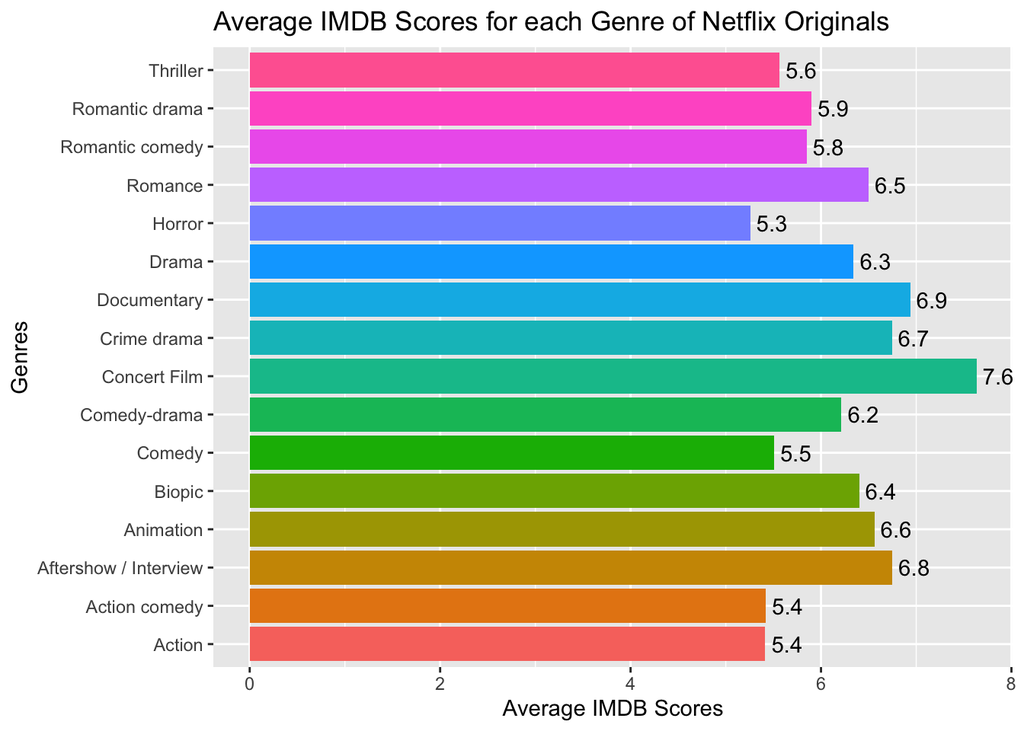

## Chart 2 Report

Chart 2 shows a Count Stack Graph for how many different languages Netflix Originals are offered in. This chart was intended to show the spread of different languages Netflix Originals are offered in, which we felt was best represented in a Count Stack Chart. Because it is a Count Stack Chart, we are easily able to see that Netflix Originals are mostly offered in English, and Originals created in other languages are more rare. Of Originals made in other languages, Spanish and Hindi content is more predominant.

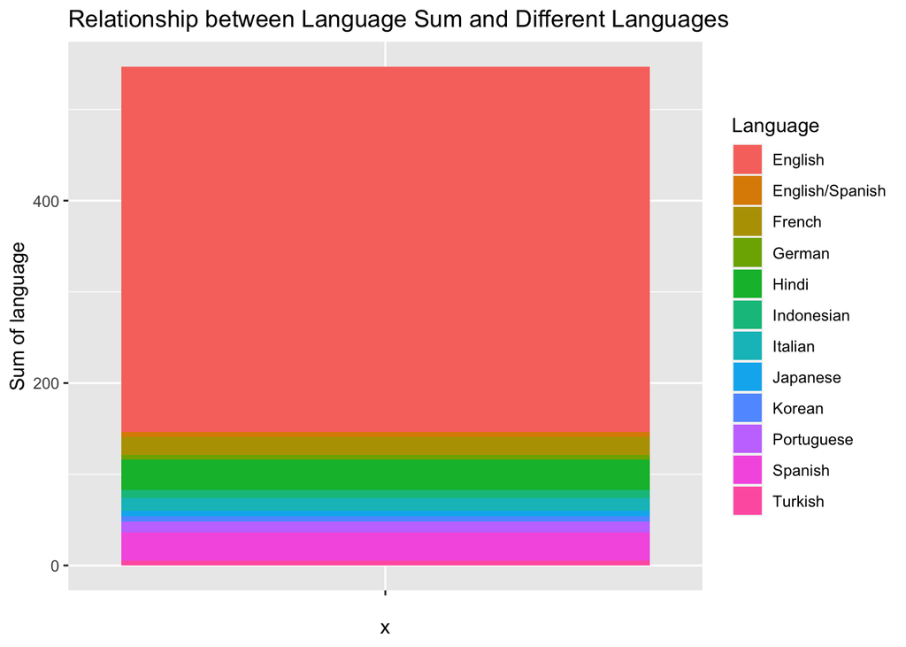

## Chart 3 Report

Chart 3 shows a line graph for the average IMDB score trend of Netflix Originals per year from 2014-2021. This chart was intended to show the relationship between the average IMDB Scores of Netflix Originals every year, which we felt was best represented in a Line Chart. Because it is a Line Chart, we are easily able to see which years Netflix Originals scored the best overall. We can see that Netflix Original Content scored the highest in 2015, with a score of 6.877, with a sharp decline of rating score in 2016, and a gradual decline every year since. 2021 Netflix Originals scored the lowest, with an average rating of 6.046.

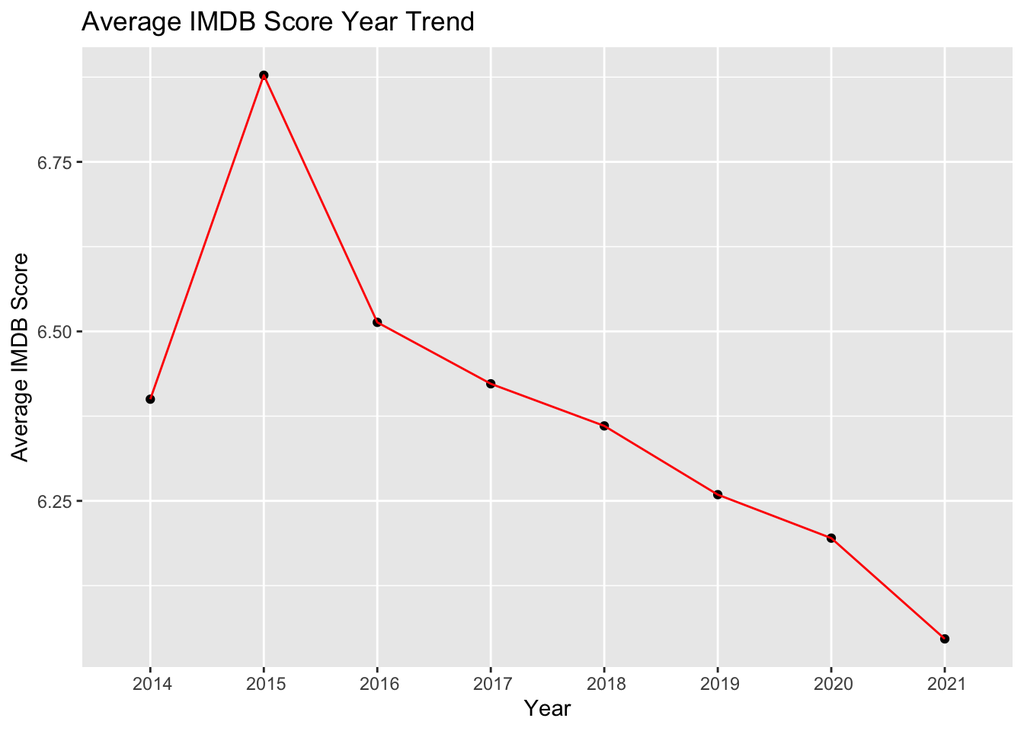